# Project - Nhóm 10

Phan Thành Đạt - Lê Chí Hiếu - Đỗ Đình Phùng - Nguyễn Anh Triều

6/16/2021

## Tập dữ liệu flight_delay

Tập dữ liệu `delay_flight` gồm các thuộc tính bên dưới (`Arr_Delay` là thuộc tính ta muốn dự đoán)

sẽ được sử dụng cho bài lab này.

| Variables | Meaning |
| --- | --- |
| Carrier | là mã của hãng máy bay vận chuyển. |
| Airport_Distance | Khoảng cách giữa 2 sân bay. |
| Number_of_flights | Số hiệu của chuyến bay. |
| Weather | Thời tiết ảnh hưởng đến thời gian của chuyến bay(tinh theo %). |
| Support_Crew_Available | Số phi hành đoàn có trên một chuyến bay. |
| Baggage_loading_time | thời gian xếp hành lý lên khoan. |
| Late_Arrival_o | Thời gian trễ. |
| Cleaning_o | Thời gian lau dọn trên máy bay trước khi bay. |
| Fueling_o | Thời gian tiếp nhiên liệu cho máy bay trước khi bay. |
| Security_o | Thời gian qua trạm kiểm soát an ninh trước khi lên may bay |
| Arr_Delay | Thời gian chuyến bay đến bị trễ |

Tập dữ liệu muốn dự đoán thời gian mà một chuyến bay đến (từ sân bay này đến sân bay khác) có thời gian bị trễ là bao nhiêu.

Giá trị đầu vào(input): “Carrier”, “Airport_Distance”, “Number_of_flights”, “Weather”, “Support_Crew_Available”, “Baggage_loading_time”,“Late_Arrival_o”, “Cleaning_o”,“Fueling_o”, “Security_o”

Giá trị cần dự đoán (Output): “Arr_Delay”

Phương pháp đánh giá: cross validation

Độ đo: confusion matrix

Nhóm sử dụng thuật toán hồi quy tuyến tính, KNN, Navie bayes, Descision Tree

## Đọc và load tập dữ liệu flight_delay

```r
# load library
library(caret)
```

```r
library(ggplot2)
#load dataset
df <- read.csv("flight_delay.csv", header = T)

# show head 6 rows
head(df)
```

|  | Carrier | Airport_Distance | Number_of_flights | Weather | Support_Crew_Available | Baggage_loading_time | Late_Arrival_o | Cleaning_o | Fueling_o | Security_o | Arr_Delay |
| --- | --- | --- | --- | --- | --- | --- | --- | --- | --- | --- | --- |
| 1 | UA | 437 | 41300 | 5 | 83 | 17 | 19 | 15 | 26 | 31 | 58 |
| 2 | UA | 451 | 41516 | 5 | 82 | 17 | 19 | 15 | 22 | 32 | 48 |
| 3 | AA | 425 | 37404 | 5 | 175 | 16 | 17 | 14 | 28 | 29 | 16 |
| 4 | B6 | 454 | 44798 | 6 | 49 | 18 | 19 | 13 | 29 | 31 | 81 |
| 5 | DL | 455 | 40643 | 6 | 55 | 17 | 19 | 18 | 26 | 37 | 62 |
| 6 | UA | 416 | 39707 | 5 | 146 | 16 | 19 | 6 | 28 | 31 | 34 |

```r
# show bottom 6 rows
tail(df)
```

|  | Carrier | Airport_Distance | Number_of_flights | Weather | Support_Crew_Available | Baggage_loading_time | Late_Arrival_o | Cleaning_o | Fueling_o | Security_o | Arr_Delay |
| --- | --- | --- | --- | --- | --- | --- | --- | --- | --- | --- | --- |
| 3588 | B6 | 431 | 43641 | 5 | 79 | 16 | 18 | 10 | 22 | 37 | 35 |
| 3589 | UA | 442 | 41793 | 6 | 120 | 17 | 19 | 8 | 26 | 42 | 57 |
| 3590 | EV | 453 | 42219 | 5 | 70 | 16 | 19 | 12 | 20 | 37 | 43 |
| 3591 | DL | 427 | 41847 | 6 | 49 | 16 | 19 | 4 | 31 | 42 | 45 |
| 3592 | B6 | 395 | 38732 | 5 | 74 | 17 | 18 | 10 | 23 | 39 | 40 |
| 3593 | B6 | 450 | 46906 | 5 | 51 | 18 | 20 | 9 | 27 | 37 | 92 |

```r
# describe the structure of data
str(df)
```

```
## 'data.frame':    3593 obs. of  11 variables:
##  $ Carrier               : chr  "UA" "UA" "AA" "B6" ...
##  $ Airport_Distance      : int  437 451 425 454 455 416 439 446 441 456 ...
##  $ Number_of_flights     : int  41300 41516 37404 44798 40643 39707 45627 40415 42248 43453 ...
##  $ Weather               : int  5 5 5 6 6 5 5 5 6 6 ...
##  $ Support_Crew_Available: int  83 82 175 49 55 146 141 145 58 3 ...
##  $ Baggage_loading_time  : int  17 17 16 18 17 16 16 17 17 18 ...
##  $ Late_Arrival_o        : int  19 19 17 19 19 19 19 18 19 19 ...
##  $ Cleaning_o            : int  15 15 14 13 18 6 15 9 9 10 ...
##  $ Fueling_o             : int  26 22 28 29 26 28 21 25 17 24 ...
##  $ Security_o            : int  31 32 29 31 37 31 39 39 53 36 ...
##  $ Arr_Delay             : int  58 48 16 81 62 34 63 47 39 122 ...
```

```r
#show the column name of the data
names(df)
```

```
##  [1] "Carrier"                "Airport_Distance"       "Number_of_flights"
##  [4] "Weather"                "Support_Crew_Available" "Baggage_loading_time"
##  [7] "Late_Arrival_o"         "Cleaning_o"             "Fueling_o"
## [10] "Security_o"             "Arr_Delay"
```

Xem thống kê

```r
# show summary
summary(df)
```

```
##    Carrier          Airport_Distance Number_of_flights    Weather
##  Length:3593        Min.   :376.0    Min.   :29475     Min.   :5.000
##  Class :character   1st Qu.:431.0    1st Qu.:41634     1st Qu.:5.000
##  Mode  :character   Median :443.0    Median :43424     Median :5.000
##                     Mean   :442.4    Mean   :43311     Mean   :5.353
##                     3rd Qu.:454.0    3rd Qu.:45140     3rd Qu.:6.000
##                     Max.   :499.0    Max.   :53461     Max.   :6.000
##  Support_Crew_Available Baggage_loading_time Late_Arrival_o    Cleaning_o
##  Min.   :  0            Min.   :14.00        Min.   :15.00   Min.   :-4.00
##  1st Qu.: 56            1st Qu.:17.00        1st Qu.:18.00   1st Qu.: 8.00
##  Median : 83            Median :17.00        Median :19.00   Median :10.00
##  Mean   : 85            Mean   :16.98        Mean   :18.74   Mean   :10.02
##  3rd Qu.:112            3rd Qu.:17.00        3rd Qu.:19.00   3rd Qu.:12.00
##  Max.   :222            Max.   :19.00        Max.   :22.00   Max.   :23.00
##    Fueling_o       Security_o      Arr_Delay
##  Min.   :13.00   Min.   :13.00   Min.   :  0.0
##  1st Qu.:23.00   1st Qu.:32.00   1st Qu.: 49.0
##  Median :25.00   Median :37.00   Median : 70.0
##  Mean   :25.01   Mean   :37.09   Mean   : 69.8
##  3rd Qu.:27.00   3rd Qu.:42.00   3rd Qu.: 90.0
##  Max.   :36.00   Max.   :63.00   Max.   :180.0
```

```r
# Vì hãng chuyến bay không phụ thuộc các biến nên ta có thể xóa
df1 <- df[-c(1)]

#Kiểm tra mối quan hệ giữa các biến
cor(df1)
```

```
##                        Airport_Distance Number_of_flights      Weather
## Airport_Distance            1.000000000        0.40561880  0.148396273
## Number_of_flights           0.405618798        1.00000000  0.247261335
## Weather                     0.148396273        0.24726133  1.000000000
## Support_Crew_Available     -0.170061773       -0.30060555 -0.110688820
## Baggage_loading_time        0.400131114        0.67192355  0.271090293
## Late_Arrival_o              0.317892412        0.57064820  0.219533717
## Cleaning_o                 -0.003433746       -0.01181124  0.006311967
## Fueling_o                  -0.037275014       -0.04282957  0.011344078
## Security_o                  0.043956588        0.07465514  0.034967545
## Arr_Delay                   0.482167140        0.82300401  0.327185319
##                        Support_Crew_Available Baggage_loading_time
## Airport_Distance                  -0.17006177           0.40013111
## Number_of_flights                 -0.30060555           0.67192355
## Weather                           -0.11068882           0.27109029
## Support_Crew_Available             1.00000000          -0.29906280
## Baggage_loading_time              -0.29906280           1.00000000
## Late_Arrival_o                    -0.24226314           0.54694337
## Cleaning_o                        -0.02756499          -0.01158070
## Fueling_o                          0.03805393          -0.00491455
## Security_o                        -0.01520496           0.07395267
## Arr_Delay                         -0.36188832           0.78363370
##                        Late_Arrival_o   Cleaning_o    Fueling_o  Security_o
## Airport_Distance           0.31789241 -0.003433746 -0.037275014  0.04395659
## Number_of_flights          0.57064820 -0.011811241 -0.042829570  0.07465514
## Weather                    0.21953372  0.006311967  0.011344078  0.03496754
## Support_Crew_Available    -0.24226314 -0.027564994  0.038053928 -0.01520496
## Baggage_loading_time       0.54694337 -0.011580701 -0.004914550  0.07395267
## Late_Arrival_o             1.00000000 -0.016692814 -0.020889830  0.08105316
## Cleaning_o                -0.01669281  1.000000000 -0.007044785 -0.01145691
## Fueling_o                 -0.02088983 -0.007044785  1.000000000  0.01664723
## Security_o                 0.08105316 -0.011456912  0.016647225  1.00000000
## Arr_Delay                  0.66683947 -0.003494777 -0.036260638  0.08007931
##                           Arr_Delay
## Airport_Distance        0.482167140
## Number_of_flights       0.823004007
## Weather                 0.327185319
## Support_Crew_Available -0.361888320
## Baggage_loading_time    0.783633696
## Late_Arrival_o          0.666839470
## Cleaning_o             -0.003494777
## Fueling_o              -0.036260638
## Security_o              0.080079308
## Arr_Delay               1.000000000
```

```r
library(caTools)
set.seed(1000)
# Tách dữ liệu với train data là 70% dataset
sample <- sample.split(df$Arr_Delay,SplitRatio=0.70)

train_data <- subset(df1,sample==TRUE)

test_data <- subset(df1,sample==FALSE)
```

Hiển thị các hình để xem các mối quan hệ trong mô hình

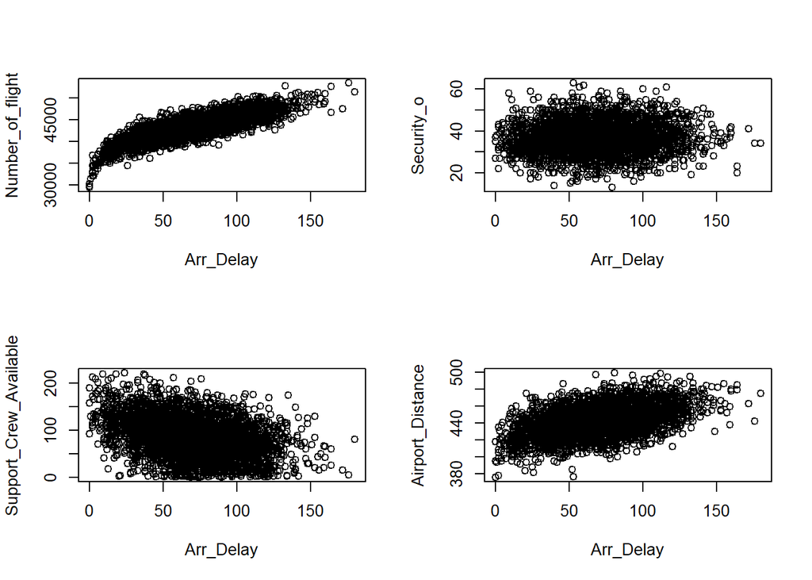

```r
par(mfrow = c(2,2))

# mô hình tương quan giữa  Arr_Delay vs Number_of_flight
plot(df$Arr_Delay,df$Number_of_flights, xlab = "Arr_Delay", ylab = "Number_of_flight")

# mô hình tương quan giữa  Arr_Delay vs Security_o
plot(df$Arr_Delay,df$Security_o,  xlab = "Arr_Delay", ylab = "Security_o")

# mô hình tương quan giữa  Arr_Delay vs Support_Crew_Available
plot(df$Arr_Delay,df$Support_Crew_Available, xlab = "Arr_Delay", ylab = "Support_Crew_Available")

# mô hình tương quan giữa  Arr_Delay vs Airport_Distance
plot(df$Arr_Delay,df$Airport_Distance,  xlab = "Arr_Delay", ylab = "Airport_Distance")
```

```r
# nhận xét: mối tương quan giữa Arr_Delay vs Number_of_flight cho thấy cả hai biến đều tỉ lệ thuận

# Kiểm tra mối tương quan giữa 2 biến
testArr <- cor.test(df$Arr_Delay,df$Number_of_flights, method = "pearson" )
testArr # quan sát kết quả cho thấy cor là 0.82 và p-value <2.2e-16 điều này nói lên giá trị p-value nhỏ hơn nhiều so với mức ý nghĩa 0.05. Do vậy hệ số tương quan trên là đáng kể
```

```
##
##  Pearson's product-moment correlation
##
## data:  df$Arr_Delay and df$Number_of_flights
## t = 86.823, df = 3591, p-value < 2.2e-16
## alternative hypothesis: true correlation is not equal to 0
## 95 percent confidence interval:
##  0.8121611 0.8332786
## sample estimates:
##      cor
## 0.823004
```

Chạy mô hình với các biến được bỏ ra

```r
# Chạy với traindata
model <- lm(formula = Arr_Delay ~.,data = train_data)
summary(model)
```

```
##
## Call:
## lm(formula = Arr_Delay ~ ., data = train_data)
##
## Residuals:
##     Min      1Q  Median      3Q     Max
## -35.780  -8.151  -0.583   8.230  70.332
##
## Coefficients:
##                          Estimate Std. Error t value Pr(>|t|)
## (Intercept)            -5.801e+02  8.943e+00 -64.861  < 2e-16 ***
## Airport_Distance        1.751e-01  1.613e-02  10.852  < 2e-16 ***
## Number_of_flights       4.418e-03  1.281e-04  34.486  < 2e-16 ***
## Weather                 4.721e+00  5.403e-01   8.737  < 2e-16 ***
## Support_Crew_Available -5.113e-02  6.398e-03  -7.991 2.03e-15 ***
## Baggage_loading_time    1.353e+01  5.238e-01  25.835  < 2e-16 ***
## Late_Arrival_o          6.999e+00  3.931e-01  17.804  < 2e-16 ***
## Cleaning_o              1.176e-01  7.106e-02   1.654   0.0982 .
## Fueling_o              -1.016e-01  7.086e-02  -1.433   0.1519
## Security_o              8.947e-03  3.505e-02   0.255   0.7985
## ---
## Signif. codes:  0 '***' 0.001 '**' 0.01 '*' 0.05 '.' 0.1 ' ' 1
##
## Residual standard error: 12.38 on 2504 degrees of freedom
## Multiple R-squared:  0.8213, Adjusted R-squared:  0.8206
## F-statistic:  1279 on 9 and 2504 DF,  p-value: < 2.2e-16
```

```r
# Nhận xét ta thấy các p-value của cleaning_o, Fueling_o, Security_o không nhỏ hơn 0.05. Do vậy các biến này không có ý nghĩa trong mô hình.
# chạy với traindata
model1 <- lm(formula = Arr_Delay ~ Airport_Distance+Number_of_flights
+Weather+Support_Crew_Available+Baggage_loading_time
+Late_Arrival_o, data= train_data)
summary(model1)
```

```
##
## Call:
## lm(formula = Arr_Delay ~ Airport_Distance + Number_of_flights +
##     Weather + Support_Crew_Available + Baggage_loading_time +
##     Late_Arrival_o, data = train_data)
##
## Residuals:
##     Min      1Q  Median      3Q     Max
## -36.224  -8.213  -0.677   8.295  70.468
##
## Coefficients:
##                          Estimate Std. Error t value Pr(>|t|)
## (Intercept)            -5.809e+02  8.705e+00 -66.734  < 2e-16 ***
## Airport_Distance        1.754e-01  1.613e-02  10.877  < 2e-16 ***
## Number_of_flights       4.424e-03  1.280e-04  34.570  < 2e-16 ***
## Weather                 4.688e+00  5.400e-01   8.683  < 2e-16 ***
## Support_Crew_Available -5.171e-02  6.394e-03  -8.087 9.38e-16 ***
## Baggage_loading_time    1.350e+01  5.232e-01  25.804  < 2e-16 ***
## Late_Arrival_o          7.007e+00  3.930e-01  17.828  < 2e-16 ***
## ---
## Signif. codes:  0 '***' 0.001 '**' 0.01 '*' 0.05 '.' 0.1 ' ' 1
##
## Residual standard error: 12.39 on 2507 degrees of freedom
## Multiple R-squared:  0.8209, Adjusted R-squared:  0.8205
## F-statistic:  1916 on 6 and 2507 DF,  p-value: < 2.2e-16
```

```r
# Tính hệ số của phương tình dự đoán

intercept <- coef(summary(model1))["(Intercept)", "Estimate"]
airport_Distance <- coef(summary(model1))["Airport_Distance", "Estimate"]
Number_of_flights <- coef(summary(model1))["Number_of_flights", "Estimate"]
Weather <- coef(summary(model1))["Weather", "Estimate"]
Support_Crew_Available <- coef(summary(model1))["Support_Crew_Available", "Estimate"]
Baggage_loading_time <- coef(summary(model1))["Baggage_loading_time", "Estimate"]
Late_Arrival_o <- coef(summary(model1))["Late_Arrival_o", "Estimate"]

y <-intercept +  airport_Distance*test_data$Airport_Distance + Number_of_flights*test_data$Number_of_flights + Weather*test_data$Weather +Support_Crew_Available*test_data$Support_Crew_Available + Baggage_loading_time*test_data$Baggage_loading_time + Late_Arrival_o*test_data$Late_Arrival_o

y
```

```
##    [1]  63.719677  66.643592  32.767436  63.250600  47.706705  71.133571
##    [7]  62.945461  71.391906 101.796594  66.466954 110.749788   9.146812
##   [13]  91.535055 131.798705  43.326122  65.574016 100.317778  42.260731
##   [19]  -7.739468  87.940364  68.099386 105.057564  71.452331  90.483461
##   [25]  20.054917  40.296356  73.508033  77.616559  67.932043  64.873166
##   [31]  67.032695  79.508439 105.828178  42.253853  22.824120  64.507404
##   [37]  45.317198  76.733144 105.192615  76.852597  48.882675  43.835347
##   [43] 103.535494  40.831527  97.322197  79.614508 115.075403 106.293703
##   [49] 101.065047  82.613977  61.216972 107.569539  52.413523  62.577759
##   [55]  63.927005  17.669405  12.025302  23.553346  75.731243  66.822389
##   [61]  54.199330  44.264086 105.907087 119.187536  36.063111  82.051330
##   [67]  45.392959  79.396919  36.475051   8.413068  83.973119  75.970902
##   [73]  93.090023  48.236419 125.247403  86.502158  51.527635 107.329784
##   [79]  76.174475 110.953210  41.299100  45.445366  51.643386 112.189011
##   [85] 112.454976  52.103108  39.015089 -12.874678  56.515578  52.357993
```

[output cut: 165 more lines]

**Nhận Xét** Nhận xét: Trong trường hợp nghiên cứu này, bình phương R là 82,09% chấp nhận tốt, có nghĩa là 82,09% chuyến bay Arr_Delay được dự đoán bởi độc lập các biến trong mô hình của chúng tôi như Airport_Distance, Weather, Number_of_flights, Support_Crew_Available, Baggage_loading_time và Late_Arrival_o.

Lọc dữ liệu và test dữ liệu

```r
# Dự đoán trong tập dữ liệu test-data

pred_test<- predict(model1,newdata = test_data, type = "response")

pred_test1<- data.frame(pred_test)
pred_test1
```

|  | pred_test |
| --- | --- |
| 2 | 63.719677 |
| 5 | 66.643592 |
| 6 | 32.767436 |
| 7 | 63.250600 |
| 8 | 47.706705 |
| 9 | 71.133571 |
| 15 | 62.945461 |
| 20 | 71.391906 |
| 23 | 101.796594 |
| 24 | 66.466954 |

[output cut: 1069 more lines]

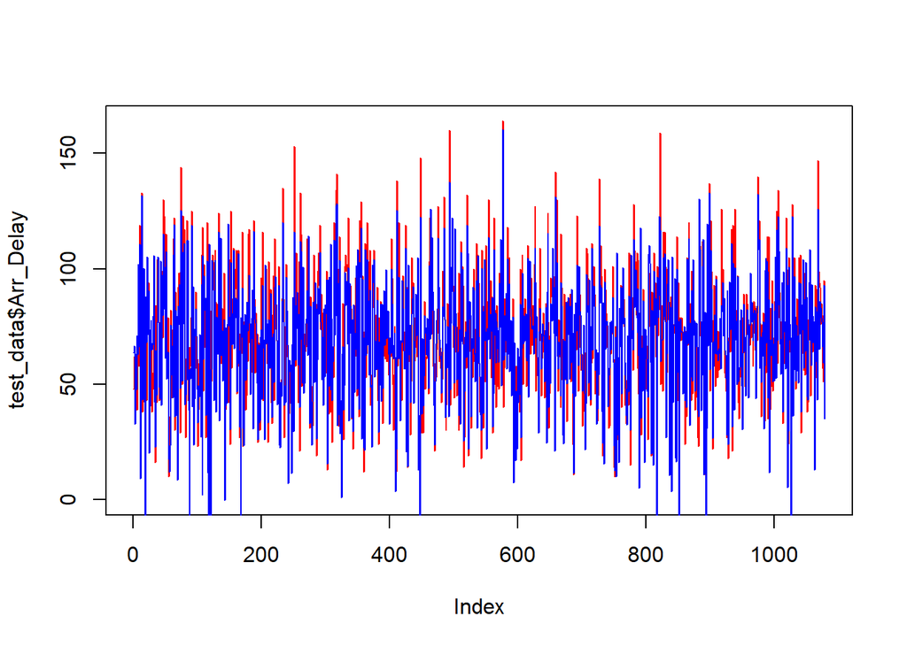

```r
#Vẽ mô hình với dữ liệu thực tế và dữ liệu train
plot (test_data$Arr_Delay,col="red",type ="l",lty=1.8)
lines(pred_test1,col="blue",type ="l",lty=1.4)
```

```r
test_data$error = test_data$Arr_Delay - pred_test
head(test_data)
```

|  | Airport_Distance | Number_of_flights | Weather | Support_Crew_Available | Baggage_loading_time | Late_Arrival_o | Cleaning_o | Fueling_o | Security_o | Arr_Delay | error |
| --- | --- | --- | --- | --- | --- | --- | --- | --- | --- | --- | --- |
| 2 | 451 | 41516 | 5 | 82 | 17 | 19 | 15 | 22 | 32 | 48 | -15.7196775 |
| 5 | 455 | 40643 | 6 | 55 | 17 | 19 | 18 | 26 | 37 | 62 | -4.6435916 |
| 6 | 416 | 39707 | 5 | 146 | 16 | 19 | 6 | 28 | 31 | 34 | 1.2325640 |
| 7 | 439 | 45627 | 5 | 141 | 16 | 19 | 15 | 21 | 39 | 63 | -0.2505995 |
| 8 | 446 | 40415 | 5 | 145 | 17 | 18 | 9 | 25 | 39 | 47 | -0.7067054 |
| 9 | 441 | 42248 | 6 | 58 | 17 | 19 | 9 | 17 | 53 | 39 | -32.1335708 |

```r
#Tính rmse
rmse = sqrt(mean(test_data$error^2))
rmse
```

```
## [1] 12.59174
```

```r
#Tính Rsquared thông qua hàm cor. Hàm cor để tính hệ số tương quan giữa 2 biến.
cor(test_data$Arr_Delay,pred_test)^2
```

```
## [1] 0.8149627
```

**Công thức tính**

Công thức hồi quy tuyến tính nhiều biến:

$$Y_i= \beta_0 + \beta_1x_{i1} + \beta_2x_{i2} + ... + \beta_px_{ip} + \epsilon$$

$$RMSE = \sqrt{\frac{\displaystyle\sum_{i=1}^n(Y_i - \hat{Y_i})^2}{n}}$$

Công thức tính R-squared trong Linear Regression:

## Xây dựng với phương pháp x-validation

```r
control = trainControl(method = "cv", number = 10)
fit = train(form = Arr_Delay ~ Airport_Distance+Number_of_flights
+Weather+Support_Crew_Available+Baggage_loading_time
+Late_Arrival_o, data=df, method ="lm", trControl = control)

fit
```

```
## Linear Regression
##
## 3593 samples
##    6 predictor
##
## No pre-processing
## Resampling: Cross-Validated (10 fold)
## Summary of sample sizes: 3235, 3234, 3235, 3233, 3234, 3234, ...
## Resampling results:
##
##   RMSE      Rsquared   MAE
##   12.45686  0.8188773  9.915612
##
## Tuning parameter 'intercept' was held constant at a value of TRUE
```

**Nhận xét** Test với phương pháp cross validation thì cũng cho ra kết quả gần đúng.

### Trên thuật toán Lasso Regression

```r
library(glmnet)
library(class)
library(caTools)
library(caret)
library(gmodels)
set.seed(1000)

df <- read.csv("flight_delay.csv", header = T)
df1 <- df[-c(1)]

data.d <- sample(1:nrow(df1),size=nrow(df1)*0.7,replace = FALSE)

traindata <- df1[data.d,]
testdata <- df1[-data.d,]

x <- data.matrix(traindata[,1:6])

x_test <- data.matrix(testdata[,1:6])

lambdas <- 10^seq(2, -6, by = -.1)

cv_model <- cv.glmnet(x, traindata$Arr_Delay, alpha = 1, lambda = lambdas)

best_lambda <- cv_model$lambda.min
best_lambda
```

```
## [1] 0.01258925
```

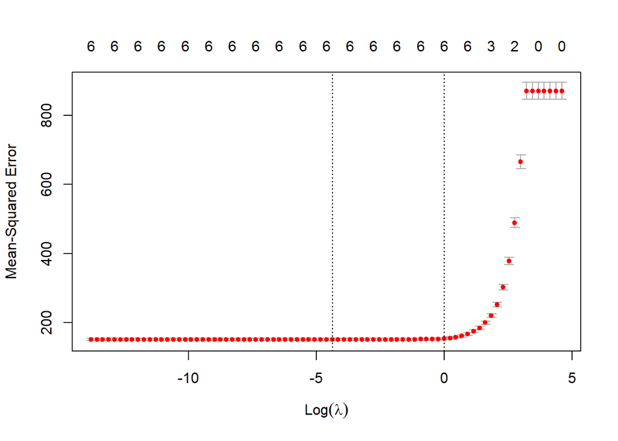

```r
plot(cv_model)
```

```r
eval_results <- function(true, predicted, df) {
  SSE <- sum((predicted - true)^2)
  SST <- sum((true - mean(true))^2)
  R_square <- 1 - SSE / SST
  RMSE = sqrt(SSE/nrow(df))
data.frame(RMSE = RMSE,Rsquare = R_square)
}

lasso_model <- glmnet(x, traindata$Arr_Delay, alpha = 1, lambda = best_lambda, standardize = TRUE)

predictions_train <- predict(lasso_model, s = best_lambda, newx = x)
eval_results(traindata$Arr_Delay, predictions_train, traindata)
```

| RMSE | Rsquare |
| --- | --- |
| 12.26728 | 0.8271006 |

```r
predictions_test <- predict(lasso_model, s = best_lambda, newx = x_test)

eval_results(testdata$Arr_Delay, predictions_test, testdata)
```

| RMSE | Rsquare |
| --- | --- |
| 12.81904 | 0.7983155 |

**Công thức**

$$\displaystyle\sum_{i=1}^n(Y_i - X_i\beta_i)^2 + \lambda\displaystyle\sum_{i=1}^n|\beta_i|=\displaystyle\sum_{i=1}^n(Y_i - \hat{Y_i})^2 + \lambda\displaystyle\sum_{i=1}^n|\beta_i| = SSE + \lambda\displaystyle\sum_{i=1}^n|\beta_i|$$

### Trên thuật toán KNN (K Nearest Neighbors)

```r
library(class)
library(caTools)
library(caret)
library(gmodels)
set.seed(1000)

df <- read.csv("flight_delay.csv", header = T)
df1 <- df[-c(1)]

# Loại bỏ biến Arr_delay vì biến này là để ta dự đoán
df1$Arr_Delay <- factor(ifelse(df1$Arr_Delay >80 ,1 ,0))

data.d <- sample(1:nrow(df1),size=nrow(df1)*0.7,replace = FALSE)

traindata_KNN <- df1[data.d,]
testdata_KNN <- df1[-data.d,]


ctrl <-trainControl(method ="cv",
                    number =10,
                    repeats=5)
customGrid <-expand.grid(k=1:60)

train(Arr_Delay~Airport_Distance+Number_of_flights
+Weather+Support_Crew_Available+Baggage_loading_time
+Late_Arrival_o,
      data=traindata_KNN,
      method = "knn",
      trControl = ctrl,
      preProcess= c("center","scale"),
      tuneGrid = customGrid,
      metric="Accuracy") -> knnFit

knnFit
```

```
## k-Nearest Neighbors
##
## 2515 samples
##    6 predictor
##    2 classes: '0', '1'
##
## Pre-processing: centered (6), scaled (6)
## Resampling: Cross-Validated (10 fold)
## Summary of sample sizes: 2263, 2264, 2263, 2264, 2264, 2263, ...
## Resampling results across tuning parameters:
##
##   k   Accuracy   Kappa
##    1  0.8190998  0.6050400
##    2  0.8186935  0.6049979
##    3  0.8509012  0.6716838
```

[output cut: 60 more lines]

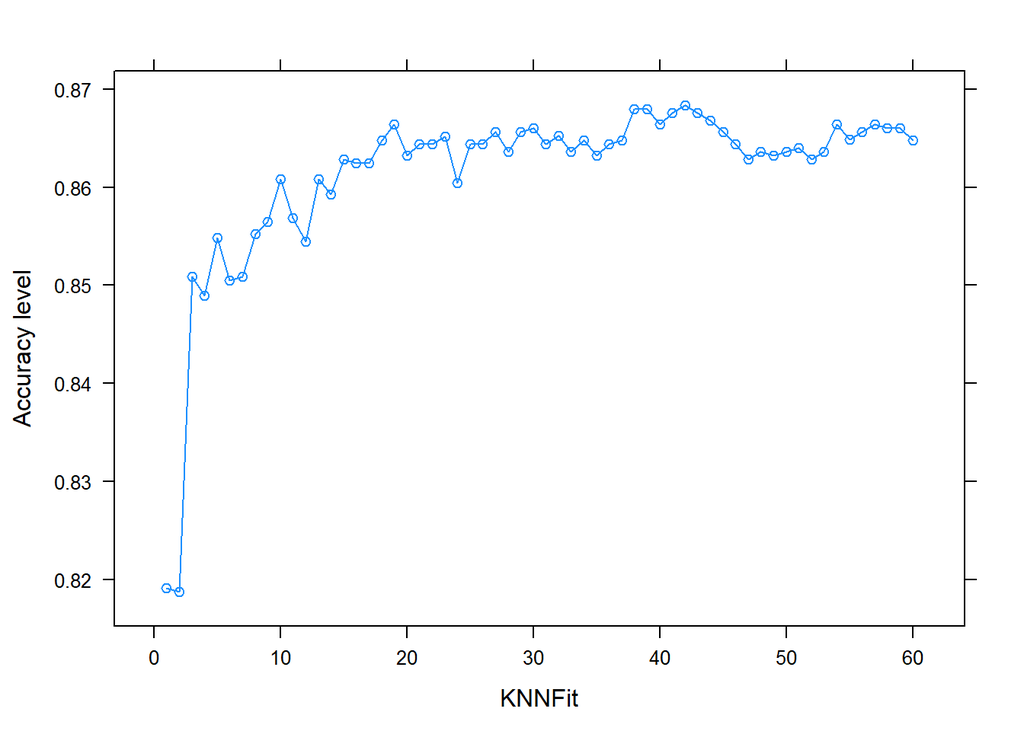

```r
plot(knnFit, type="b",col = "dodgerblue", xlab="KNNFit",ylab="Accuracy level")
```

```r
pred_test <-predict(knnFit, newdata = testdata_KNN)

confusionMatrix(pred_test, testdata_KNN$Arr_Delay)
```

```
## Confusion Matrix and Statistics
##
##           Reference
## Prediction   0   1
##          0 650 117
##          1  44 267
##
##                Accuracy : 0.8506
##                  95% CI : (0.828, 0.8714)
##     No Information Rate : 0.6438
##     P-Value [Acc > NIR] : < 2.2e-16
##
##                   Kappa : 0.6599
##
##  Mcnemar's Test P-Value : 1.392e-08
##
##             Sensitivity : 0.9366
##             Specificity : 0.6953
##          Pos Pred Value : 0.8475
##          Neg Pred Value : 0.8585
##              Prevalence : 0.6438
##          Detection Rate : 0.6030
##    Detection Prevalence : 0.7115
##       Balanced Accuracy : 0.8160
##
##        'Positive' Class : 0
##
```

```r
cat("Accuracy = ",sum(testdata_KNN$Arr_Delay==pred_test)/(nrow(testdata_KNN)),"\n")
```

```
## Accuracy =  0.8506494
```

```r
cat("sensitivity = Precision =  ",sensitivity(pred_test,testdata_KNN$Arr_Delay),"\n")
```

```
## sensitivity = Precision =   0.9365994
```

```r
cat("specificity = ",specificity(pred_test,testdata_KNN$Arr_Delay), "\n")
```

```
## specificity =  0.6953125
```

```r
cat("posPredValue = recall = ",posPredValue(pred_test, testdata_KNN$Arr_Delay),"\n")
```

```
## posPredValue = recall =  0.8474576
```

```r
cat("negPredValue = ",negPredValue(pred_test, testdata_KNN$Arr_Delay),"\n")
```

```
## negPredValue =  0.8585209
```

```r
cat("F_measure = ",2 * ((sensitivity(pred_test,testdata_KNN$Arr_Delay) *posPredValue(pred_test, testdata_KNN$Arr_Delay)) / (sensitivity(pred_test,testdata_KNN$Arr_Delay) + posPredValue(pred_test, testdata_KNN$Arr_Delay))),"\n")
```

```
## F_measure =  0.8898015
```

**Nhận xét**

|  | Positive | Negetive | Total |
| --- | --- | --- | --- |
| Positive | 650 | 117 | 767 |
| Negetive | 44 | 267 | 311 |
| Total | 694 | 384 | 1078 |

- $$P_0 = Accuracy = 0.8506$$
- $$P_e = \displaystyle\sum_{i=1}^n(\frac{n_i}{N}* \frac{m_i}{N}) = (\frac{767}{1078}* \frac{694}{1078}) + (\frac{311}{1078}* \frac{384}{1078}) = 0.55997$$
- $$Kappa = \frac{P_0 - P_e}{1-P_e} = \frac{ 0.8506 - 0.55997}{1-0.55997} = 0.66$$
- Hệ số Kappa là hệ số được sử dụng để đánh giá hiệu suất của một mô hình phân loại.  
  Kappa <0: Không đồng ý.  
  Kappa từ 0,00 đến 0,20: Thoả thuận nhẹ.  
  Kappa từ 0,21 đến 0,40: Thỏa thuận công bằng.  
  Kappa từ 0,41 đến 0,60: Thỏa thuận vừa phải.  
  Kappa giữa 0,61 và 0,80: Thỏa thuận đáng kể.  
  Kappa giữa 0,81 và 1,00: Thỏa thuận gần như hoàn hảo.

### Thuật toán Navie Bayes

```r
library(class)
library(caTools)
library(e1071)
library(caret)
set.seed(1000)

df <- read.csv("flight_delay.csv", header = T)

df1 <- df[-c(1)]

df1$Arr_Delay <- factor(ifelse(df1$Arr_Delay >80 ,1 ,0))

indxTrain <- createDataPartition(y = df1$Arr_Delay,p = 0.7,list = FALSE)
training <- df1[indxTrain,]
testing <- df1[-indxTrain,]


ctrl <- trainControl(method="cv",repeats = 5)
nbFit <- train(Arr_Delay ~ Airport_Distance+Number_of_flights+Weather+Support_Crew_Available+Baggage_loading_time+Late_Arrival_o,
                 data = training,
                 method = "naive_bayes",
                trControl = ctrl,
                 preProcess = c("center","scale"),
                metric="Accuracy")
nbFit
```

```
## Naive Bayes
##
## 2516 samples
##    6 predictor
##    2 classes: '0', '1'
##
## Pre-processing: centered (6), scaled (6)
## Resampling: Cross-Validated (10 fold)
## Summary of sample sizes: 2265, 2264, 2264, 2264, 2264, 2264, ...
## Resampling results across tuning parameters:
##
##   usekernel  Accuracy   Kappa
##   FALSE      0.8561184  0.6937743
##    TRUE      0.8644612  0.7063586
##
## Tuning parameter 'laplace' was held constant at a value of 0
## Tuning
##  parameter 'adjust' was held constant at a value of 1
## Accuracy was used to select the optimal model using the largest value.
## The final values used for the model were laplace = 0, usekernel = TRUE
##  and adjust = 1.
```

```r
predict(nbFit, newdata = testing) -> pred_test
confusionMatrix(pred_test, testing$Arr_Delay)
```

```
## Confusion Matrix and Statistics
##
##           Reference
## Prediction   0   1
##          0 623  81
##          1  71 302
##
##                Accuracy : 0.8589
##                  95% CI : (0.8366, 0.8791)
##     No Information Rate : 0.6444
##     P-Value [Acc > NIR] : <2e-16
##
##                   Kappa : 0.6902
##
##  Mcnemar's Test P-Value : 0.4654
##
##             Sensitivity : 0.8977
##             Specificity : 0.7885
##          Pos Pred Value : 0.8849
##          Neg Pred Value : 0.8097
##              Prevalence : 0.6444
##          Detection Rate : 0.5785
##    Detection Prevalence : 0.6537
##       Balanced Accuracy : 0.8431
##
##        'Positive' Class : 0
##
```

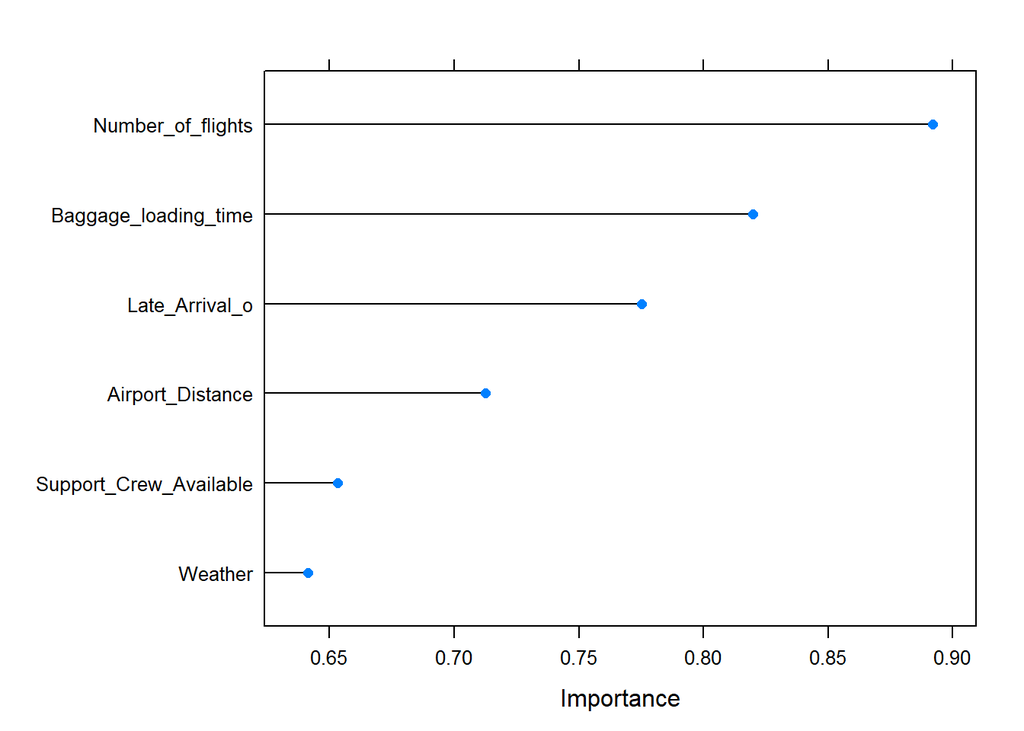

```r
varImp(nbFit, scale = FALSE) ->importance_nb
plot(importance_nb)
```

```r
cat("Accuracy = ",sum(testing$Arr_Delay==pred_test)/(nrow(testing)),"\n")
```

```
## Accuracy =  0.8588672
```

```r
cat("sensitivity = Precision =  ",sensitivity(pred_test,testing$Arr_Delay),"\n")
```

```
## sensitivity = Precision =   0.8976945
```

```r
cat("specificity = ",specificity(pred_test,testing$Arr_Delay), "\n")
```

```
## specificity =  0.7885117
```

```r
cat("posPredValue = recall = ",posPredValue(pred_test, testing$Arr_Delay),"\n")
```

```
## posPredValue = recall =  0.8849432
```

```r
cat("negPredValue = ",negPredValue(pred_test, testing$Arr_Delay),"\n")
```

```
## negPredValue =  0.8096515
```

```r
cat("F_measure = ",2 * ((sensitivity(pred_test,testing$Arr_Delay) *posPredValue(pred_test, testing$Arr_Delay)) / (sensitivity(pred_test,testing$Arr_Delay) + posPredValue(pred_test, testing$Arr_Delay))),"\n")
```

```
## F_measure =  0.8912732
```

**Nhận xét thuật toán Navie bayes**

- Độ chính xác của thuật toán Navie bayes cho tập dữ liệu là 85.89% .
- $$Accuracy = \frac{TP + TN}{TP + TN + FP + FN} = \frac{623 + 302}{623 + 302 + 71 + 81} = 0.8589$$
- $$Pos_Pred_Value = Recall = \frac{TP}{TP + FN} = \frac{623}{623 + 81} = 0.8849$$
- $$Neg Pred Value = \frac{TN}{TN + FP} = \frac{302}{302 + 71} = 0.8097$$
- $$Sensitivity = Precision = \frac{TP}{TP + FP} = \frac{623}{623 + 71} = 0.8977$$
- $$Specificity = \frac{TN}{TN + FN} = \frac{302}{302 + 81} = 0.7885$$
- $$Kappa = \frac{P_0 - P_e}{1-P_e}$$
  **Bảng giá trị**

|  | Positive | Negetive | Total |
| --- | --- | --- | --- |
| Positive | 623 | 81 | 704 |
| Negetive | 71 | 302 | 373 |
| Total | 694 | 383 | 1077 |

- $$P_0 = Accuracy = 0.8589$$
- $$P_e = \displaystyle\sum_{i=1}^n(\frac{n_i}{N}* \frac{m_i}{N}) = (\frac{704}{1077}* \frac{694}{1077}) + (\frac{373}{1077}* \frac{383}{1077}) = 0.5444$$
- $$Kappa = \frac{P_0 - P_e}{1-P_e} = \frac{0.8589 - 0.5444}{1-0.5444} = 0.6903$$

### Thuật toán Descision Tree

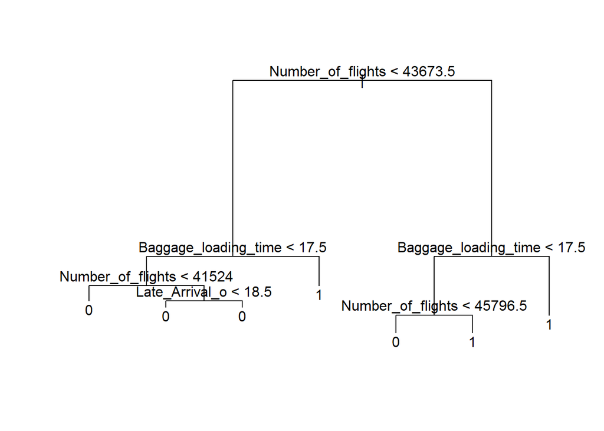

```r
library(caTools)
library(class)
library(tree)
library(caret)
set.seed(1000)

df <- read.csv("flight_delay.csv", header = T)

df1 <- df[-c(1)]

df1$Arr_Delay <- factor(ifelse(df1$Arr_Delay >80 ,1 ,0))

indxTrain <- createDataPartition(y = df1$Arr_Delay,p = 0.7,list = FALSE)
#indxTrain <- sort(sample(nrow(df1), nrow(df1)*.7))

training <- df1[indxTrain,]
testing <- df1[-indxTrain,]
tree(Arr_Delay~Airport_Distance+Number_of_flights+Weather+Support_Crew_Available+Baggage_loading_time+Late_Arrival_o, data=training) ->treeRaw

plot(treeRaw)
text(treeRaw)
```

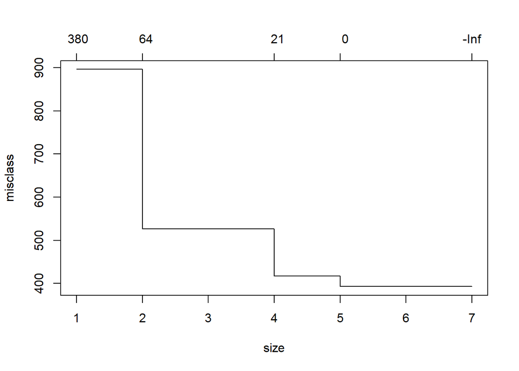

```r
cv_tree<-cv.tree(treeRaw, FUN=prune.misclass)

plot(cv_tree)
```

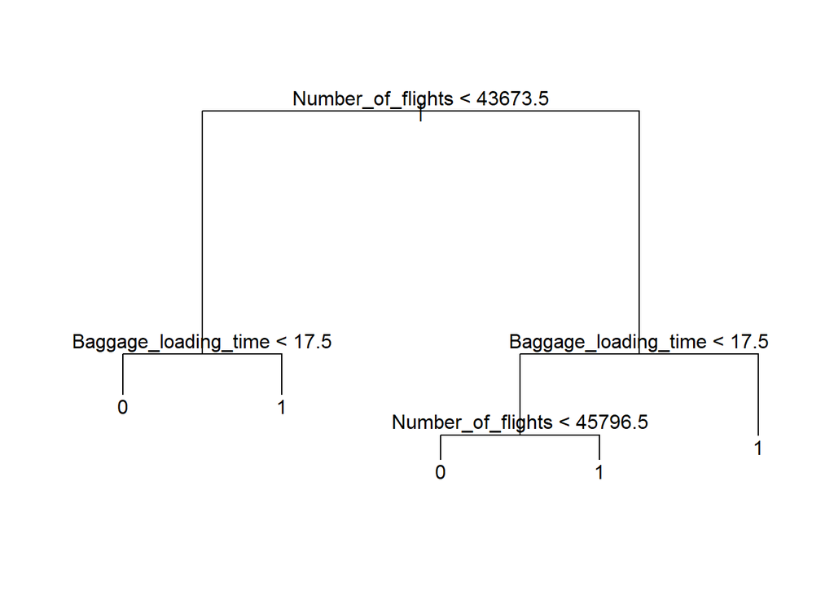

```r
prune.misclass(treeRaw, best=5) -> prune_tree
plot(prune_tree)
text(prune_tree, pretty=0)
```

```r
predict(prune_tree, testing, type='class') -> pred_test
confusionMatrix(pred_test, testing$Arr_Delay)
```

```
## Confusion Matrix and Statistics
##
##           Reference
## Prediction   0   1
##          0 653 126
##          1  41 257
##
##                Accuracy : 0.8449
##                  95% CI : (0.8219, 0.8661)
##     No Information Rate : 0.6444
##     P-Value [Acc > NIR] : < 2.2e-16
##
##                   Kappa : 0.644
##
##  Mcnemar's Test P-Value : 8.026e-11
##
##             Sensitivity : 0.9409
##             Specificity : 0.6710
##          Pos Pred Value : 0.8383
##          Neg Pred Value : 0.8624
##              Prevalence : 0.6444
##          Detection Rate : 0.6063
##    Detection Prevalence : 0.7233
##       Balanced Accuracy : 0.8060
##
##        'Positive' Class : 0
##
```

```r
cat("Accuracy = ",sum(testing$Arr_Delay==pred_test)/(nrow(testing)),"\n")
```

```
## Accuracy =  0.8449396
```

```r
cat("sensitivity = Precision =  ",sensitivity(pred_test,testing$Arr_Delay),"\n")
```

```
## sensitivity = Precision =   0.9409222
```

```r
cat("specificity = ",specificity(pred_test,testing$Arr_Delay), "\n")
```

```
## specificity =  0.6710183
```

```r
cat("posPredValue = recall = ",posPredValue(pred_test, testing$Arr_Delay),"\n")
```

```
## posPredValue = recall =  0.8382542
```

```r
cat("negPredValue = ",negPredValue(pred_test, testing$Arr_Delay),"\n")
```

```
## negPredValue =  0.8624161
```

```r
cat("F_measure = ",2 * ((sensitivity(pred_test,testing$Arr_Delay) *posPredValue(pred_test, testing$Arr_Delay)) / (sensitivity(pred_test,testing$Arr_Delay) + posPredValue(pred_test, testing$Arr_Delay))),"\n")
```

```
## F_measure =  0.8866259
```

**Nhận xét thuật toán Descision Tree**

|  | Positive | Negetive | Total |
| --- | --- | --- | --- |
| Positive | 653 | 126 | 779 |
| Negetive | 41 | 257 | 298 |
| Total | 694 | 383 | 1077 |

### Tóm tắt và kết luận

- Du lịch bằng máy bay là một thách thức với thời gian bay đến và đi không nhất quán. Việc hoãn chuyến bay không chỉ gây tốn kém cho các hãng hàng không mà còn khiến du khách bức xúc hơn. Các yếu tố nào ảnh hưởng đến thời gian đến của chuyến bay. Do vậy mà các hãng hàng không quyết định dự và tìm ra yếu tố nào ảnh hưởng đến thời gian đến của một chuyến bay.
- Tập dữ liệu gồm tổng số 3.593 quan sát và 11 biến; 10 biến là số và 1 biến là phân loại. Arr_Delay là biến phụ thuộc hoặc gọi là biến dự đoán.
- Nhóm đã sử dụng các thuật toán Linear Regression, KNN (K-Nearest Neighbors), Navie bayes, Descision tree, phương pháp đánh giá là cross validation, Độ đo confusion matrix.
- Kết quả dự đoán được từ những thuật toán trên là biến Number_of_flight là biến ảnh hưởng nhiều nhất đến Arr_delay. Nhóm đã hiểu được ý nghĩa của các thuật toán phân loại(classification) trong môn học.
- Nếu có thêm thời gian nhóm sẽ tìm hiểu thêm các thuật toán khác về dạng phân loại như SVM. Thực hiện thuật toán trên ngôn ngữ Python
- Tài liệu tham khảo: https://www.analyticsvidhya.com/blog/2015/08/learning-concept-knn-algorithms-programming/  
  https://www.guru99.com/r-decision-trees.html  
  Tham khảo từ sách:Applied analytics through case studies using SAS and R implementing predictive models and machine learning techniques by Gupta, Deepti (z-lib.org).pdf

### Câu hỏi

- Cái output của các bạn là biến liên tục vậy tại sao bạn lại lựa chọn các thuật toán vào nhóm phân loại như là knn, naive bayes và Ủa bạn ơi cho mình hỏi là biến dự đoán là độ trễ chuyến bay vậy tại sao lại gom phân loại và hồi quy tuyến tính vào chung 1 bài.
- Nhóm mình sử dụng 2 dạng thuật toán một là dạng hồi quy, hai là dạng phân loại.Dạng thứ nhất thì dạng hồi quy nhóm mình có trình bày Linear Regression và Lasso Regression để tìm ra yếu tố ảnh hưởng đến thời gian bay đến của chuyến bay và dự đoán thời gian bay đến bị trễ.Dạng thứ hai là dạng thuật toán phân loại như KNN, Navies bayes, Descision tree, thì nhóm mình muốn thử xem như bài toán hồi quy thì có cách nào để thực hiện ở dạng phân loại hay không? Từ đó, nhóm mình quyết định làm thuật toán này để hiểu rõ hơn cách hoạt động của các thuật toán, để thực hiện thì nhóm mình đã đưa biến giải thích(biến dự đoán) về dạng nhị phân(0 và 1) thì và từ đó mình xây dựng mô hình các thuật toán và xem xét thuật toán nào có cho kết quả tốt nhất thông qua 2 hệ số đánh giá (Accuracy và Kappa).
- Làm sao biết được con số đó là chuẩn để đưa về biến dummy?
- Thì ở đây biến giải thích của nhóm mình (Arr_delay) có min = 0, Q1 = 49, median = 70, mean = 69.8 , Q3 = 90, max = 180 thì nhóm mình chọn giá trị là 80 vì nó nằm trong khoảng cho phép Q1 <= Gt <= Q3 <=> 49 <= 80 <= 90. Nếu chọn giá trị nằm ngoài khoảng này thì giá trị không đúng vì những giá trị đó là giá trị ngoài rìa.